# Time Series Homework: Chapter 2 Lesson 2

Eduardo Ramirez

## Data

```r
manu4 <- rio::import("https://byuistats.github.io/timeseries/data/manu_mat_invent.csv")

earlier <- rio::import("https://raw.githubusercontent.com/1Ramirez7/uni_data/refs/heads/main/data/mearlier.csv")

latter <- rio::import("https://raw.githubusercontent.com/1Ramirez7/uni_data/refs/heads/main/data/mlatter.csv")
```

## Questions

### Question 1 - Context and Measurement (10 points)

The first part of any time series analysis is context. You cannot properly analyze data without knowing what the data is measuring. Without context, the most simple features of data can be obscure and inscrutable. This homework assignment will center around the series below.

Please research the time series. In the spaces below, give the data collection process, unit of analysis, and meaning of each observation for the series.

#### **Manufacturers’ Materials and Supplies Inventories**

https://fred.stlouisfed.org/series/UMTMMI

**Answer**

- **Data Collection Process**: The data is collected monthly by the U.S. Census Bureau and represents manufacturers’ inventories for materials and supplies across the manufacturing sector in the U.S.
- **Unit of Analysis**: The values are measured in millions of dollars, indicating the monetary worth of materials and supplies inventories at the end of each month.
- **Meaning of Each Observation**: Each observation represents the total dollar value of materials and supplies inventories held by U.S. manufacturers at the end of the specified month, without adjustments for seasonal variations.

```r
manu4$date <- lubridate::mdy(manu4$date) # manu_1
manu4$date <- yearmonth(manu4$date) # manu_2
manu4$manu_inv <- as.numeric(manu4$manu_inv) # manu_3

missing_values <- anyNA(manu4$manu_inv) | anyNA(manu4$date) # this portion only checks for missing and the above line of code is what changes the df
if (anyNA(manu4$manu_inv) | anyNA(manu4$date)) {
  cat("Missing values in 'manu_inv' or 'date'.\n")
} else {
  cat("No missing values.\n")
} # manu_3 only checks for NA
```

```
No missing values.
```

```r
manu4_tsbl <- as_tsibble(manu4, key = NULL, index = date, regular = TRUE) # manu_4
interval(manu4_tsbl) # checks for interval
```

```
<interval[1]>
[1] 1M
```

```r
has_gaps(manu4_tsbl) # checks for gaps
```

```
# A tibble: 1 × 1
  .gaps
  <lgl>
1 FALSE
```

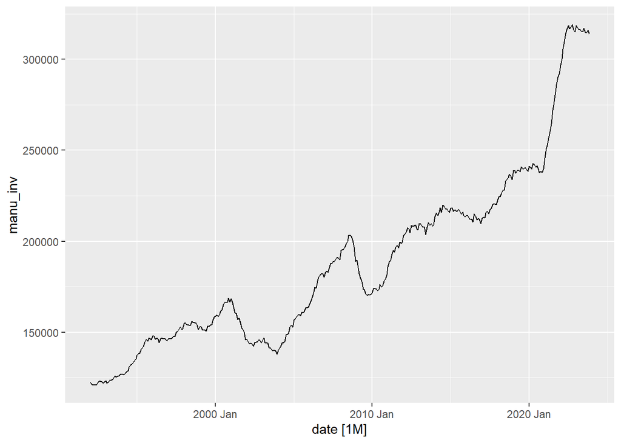

```r
# manu4_tsbl <- manu4_tsbl %>% fill_gaps() # to fill gaps # manu_4

manu4_tsbl |>
    autoplot()
```

```r
#manu4_tsbl |>
#    slice(1:12) |> # this code just plots the first 12 rows.
#    autoplot()
```

### Question 2 - Manufacturer’s Inventory: Autocorrelation and autocovariance (10 points)

#### a) Please calculate the list of autocorrelation and autocovariance values for the Manufacturer’s Inventory series.

**Answer**

# Autocorrelation Values for the Manufacture’s Inventory

```r
# autocorrelation values for the manufacture's inventory
manu4_tsbl |> ACF(manu_inv)
```

```
# A tsibble: 25 x 2 [1M]
        lag   acf
   <cf_lag> <dbl>
 1       1M 0.988
 2       2M 0.976
 3       3M 0.963
 4       4M 0.949
 5       5M 0.934
 6       6M 0.920
 7       7M 0.904
 8       8M 0.889
 9       9M 0.873
10      10M 0.856
# ℹ 15 more rows
```

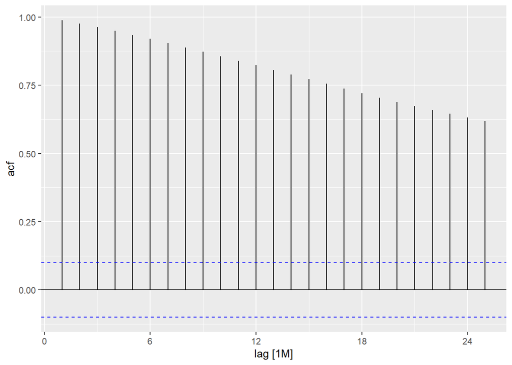

```r
ACF(manu4_tsbl) |> autoplot()
```

**Answer**

# Autocovariance Values for the Manufacture’s Inventory Series

```r
manu4_tsbl |> ACF(manu_inv, type = "covariance")
```

```
# A tsibble: 25 x 2 [1M]
        lag         acf
   <cf_lag>       <dbl>
 1       1M 2364790710.
 2       2M 2334722786.
 3       3M 2303877261.
 4       4M 2270652440.
 5       5M 2235855386.
 6       6M 2201015019.
 7       7M 2164212123.
 8       8M 2126778125.
 9       9M 2089074989.
10      10M 2049563630.
# ℹ 15 more rows
```

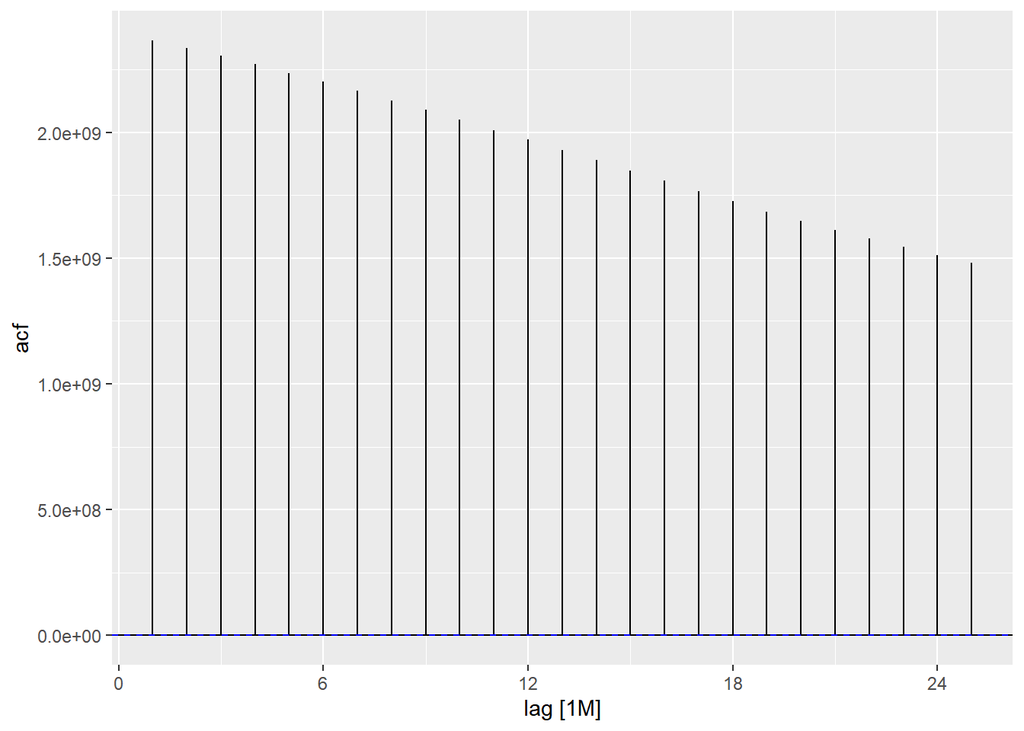

```r
ACF(manu4_tsbl, type = "covariance") |> autoplot()
```

#### b) If autocovariance and autocorrelation are trying to evaluate a similar linear relationship across time in our series, why do we get different values for autocorrelation and autocovariance at the same lag.

**Answer**

Autocovariance and autocorrelation both measure the linear relationship between a time series and its lagged values, but they differ in scale. Autocovariance reflects the raw magnitude of dependence, while autocorrelation is a standardized version that divides by the variance, yielding values between -1 and 1 for easy comparison. This is why autocovariance values are large (in original units) and autocorrelation values are always between -1 and 1, even at the same lag.

### Question 3 - Manufacturer’s Inventory: Stationary (20 points)

Weak stationarity is a form of stationarity important for the analysis of time series data. A time series is said to be weakly stationary if its statistical properties such as mean, variance, and autocovariance are constant over time. Here are the key components of weak stationarity:

*Constant Mean:* The mean of the time series remains constant over time. This doesn’t necessarily mean that the time series is centered around zero; it just implies that the average value remains the same throughout the observed period.

*Constant Variance:* The variance of the time series is uniform across all time points. Like the mean, this doesn’t imply that the variance must be zero, just that it doesn’t change systematically with time.

*Constant Autocovariance:* The autocovariance between any two observations of the time series depends only on the time lag between them and not on the absolute positions of the observations in time. This implies that the dependence structure of the time series remains constant over time.

#### a) Please split the time series into two halves according to the date recorded, the earlier half of the data and the latter part of the data. Calculate the mean, variance, and autocovariance for each half. *Note:* *(it doesn’t really matter if it’s precisely half. An approximate middle is sufficient.)*

**Answer**

```r
earlier$date <- lubridate::mdy(earlier$date) # manu_1
earlier$date <- yearmonth(earlier$date) # manu_2
earlier$manu_inv <- as.numeric(earlier$manu_inv) # manu_3
earlier_tsbl <- as_tsibble(earlier, key = NULL, index = date, regular = TRUE) # manu_4

mean_earlier <- mean(earlier_tsbl$manu_inv, na.rm = TRUE)
var_earlier <- var(earlier_tsbl$manu_inv, na.rm = TRUE)

cat("Earlier Autocovariance table & Plot")
```

```
Earlier Autocovariance table & Plot
```

```r
earlier_tsbl |> ACF(manu_inv, type = "covariance")
```

```
# A tsibble: 22 x 2 [1M]
        lag        acf
   <cf_lag>      <dbl>
 1       1M 271864918.
 2       2M 263934953.
 3       3M 255685221.
 4       4M 246527856.
 5       5M 237030968.
 6       6M 227618413.
 7       7M 217212817.
 8       8M 207420675.
 9       9M 198025275.
10      10M 187730547.
# ℹ 12 more rows
```

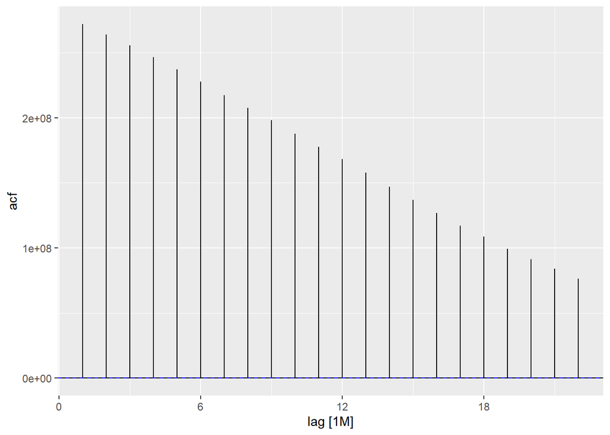

```r
ACF(earlier_tsbl, type = "covariance") |> autoplot()
```

```r
latter$date <- lubridate::mdy(latter$date) # manu_1
latter$date <- yearmonth(latter$date) # manu_2
latter$manu_inv <- as.numeric(latter$manu_inv) # manu_3
latter_tsbl <- as_tsibble(latter, key = NULL, index = date, regular = TRUE) # manu_4

mean_latter <- mean(latter_tsbl$manu_inv, na.rm = TRUE)
var_latter <- var(latter_tsbl$manu_inv, na.rm = TRUE)

cat("Latter Autocovariance table & Plot")
```

```
Latter Autocovariance table & Plot
```

```r
latter_tsbl |> ACF(manu_inv, type = "covariance")
```

```
# A tsibble: 22 x 2 [1M]
        lag         acf
   <cf_lag>       <dbl>
 1       1M 1568354967.
 2       2M 1540251678.
 3       3M 1511153596.
 4       4M 1478539410.
 5       5M 1443884911.
 6       6M 1409207644.
 7       7M 1371666130.
 8       8M 1333456667.
 9       9M 1294884311.
10      10M 1253651023.
# ℹ 12 more rows
```

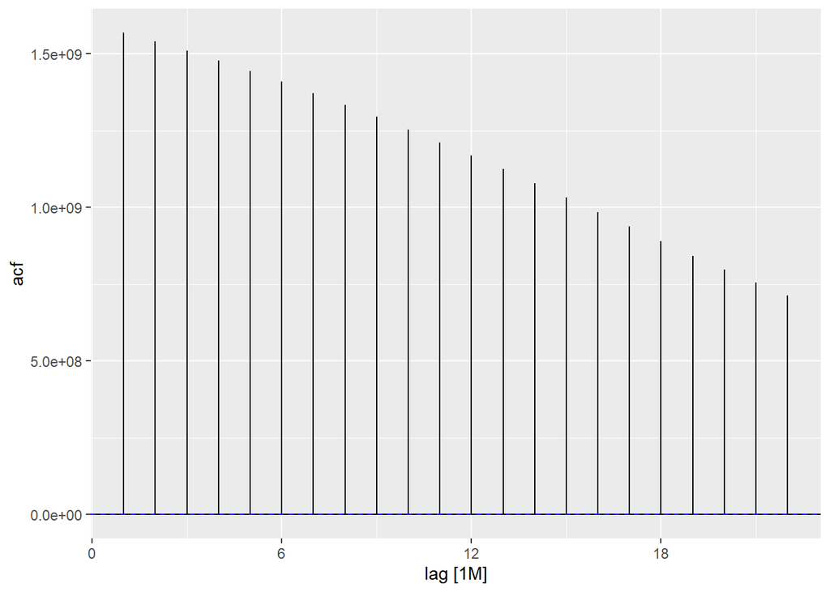

```r
ACF(latter_tsbl, type = "covariance") |> autoplot()
```

```r
cat("Earlier Mean:", mean_earlier, "\n")
```

```
Earlier Mean: 149865
```

```r
cat("Latter mean:", mean_latter, "\n")
```

```
Latter mean: 226136.7
```

```r
cat("Earlier Variance:", var_earlier, "\n")
```

```
Earlier Variance: 280707884
```

```r
cat("Latter Variance:", var_latter, "\n")
```

```
Latter Variance: 1603110465
```

#### b) Is there evidence to suggest that the Manufacturer’s Inventory series is weakly stationary?

**Answer**

weakly stationary? what is weakly??

In order for a data to be stationary, any two periods in a data-set would have the same mean and variance. In the case for the Manu data set. the mean and variance for both the earlier & latter data sets are different so to that definition this data set is not stationary but maybe it is weakly stationary?  
here is chatgpt’s summarizing my results and thoughts for this question.

The Manufacturer’s Inventory series does not appear to be weakly stationary since the mean, variance, and autocovariance differ substantially between the earlier and latter halves of the data. The significant increase in mean and variance over time indicates that the statistical properties of the series are not constant.

#### c) The variance function for a times series, $\sigma^2(t)=E[(x_t-\mu)^2]$, is defined for the entire ensemble. Why is determining whether a time series has constant variance so difficult using sample data?

**Answer**

Well, first seasonality and randomness can effect the variance at different points, and doing the variance for just a sample data can missed shocks in the dataset.  
here is chatgpt’s summary of my results and thoughts.  
Determining whether a time series has constant variance is difficult using sample data because the variance function, defined for the entire ensemble, must ideally consider all possible realizations of the process. In practice, we only have a finite sample, which makes it challenging to accurately assess whether variance is stable, especially in the presence of trends or other systematic changes over time.

### Rubric

[output not shown]

Back to top